# Melchizedek Ackah-Blay

```python
df_mar = df[df['birth_year'] < 2005]
a = pd.DataFrame(df_mar.groupby('maritaldesc')['birth_year'].mean().sort_values(ascending = False))
a.columns = ['Average Birth Year']
a
```

| maritaldesc | Average Birth Year |
| --- | --- |
| Married | 1982.727273 |
| Separated | 1981.750000 |
| Single | 1981.241935 |
| Widowed | 1979.400000 |
| Divorced | 1979.388889 |

10. How many employees of each **gender** and **race** were terminated for poor performance?

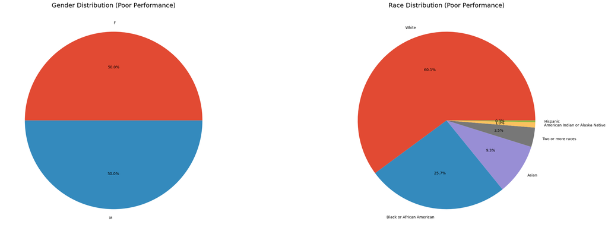

```python
df_ter = df[df['termreason'] == 'performance']
ge_dist = df_ter['sex'].value_counts()
rc_dist = df['racedesc'].value_counts()

plt.figure(figsize = (27,27))
plt.subplot(1,2,1)
ge_dist.plot(kind = 'pie', autopct = '%1.1f%%')
plt.title('Gender Distribution (Poor Performance)', fontsize = 17)
plt.xlabel('')
plt.ylabel('')

plt.subplot(1,2,2)
rc_dist.plot(kind = 'pie', autopct = '%1.1f%%')
plt.title('Race Distribution (Poor Performance)', fontsize = 17)
plt.xlabel('')
plt.ylabel('')
plt.subplots_adjust(wspace = 0.5)
plt.show()
```

11. How many employees of each **gender** and **race** left for another position?

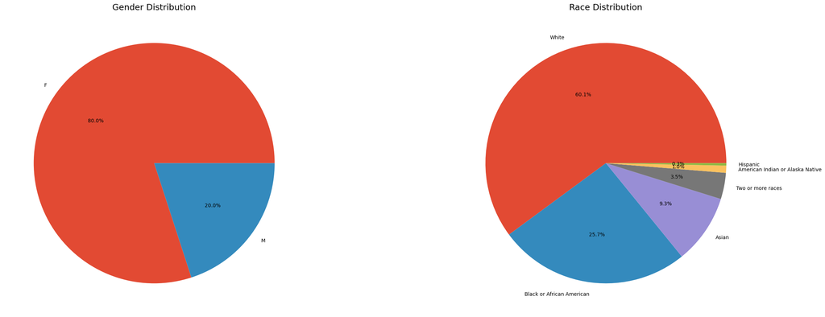

```python
df_ter = df[df['termreason'] == 'Another position']
ge_dist = df_ter['sex'].value_counts()
rc_dist = df['racedesc'].value_counts()

plt.figure(figsize = (27,27))
plt.subplot(1,2,1)
ge_dist.plot(kind = 'pie', autopct = '%1.1f%%')
plt.title('Gender Distribution', fontsize = 17)
plt.xlabel('')
plt.ylabel('')

plt.subplot(1,2,2)
rc_dist.plot(kind = 'pie', autopct = '%1.1f%%')
plt.title('Race Distribution', fontsize = 17)
plt.xlabel('')
plt.ylabel('')
plt.subplots_adjust(wspace = 0.5)
plt.show()
```

12. How many employees of each **gender** and **race** left for a career change?

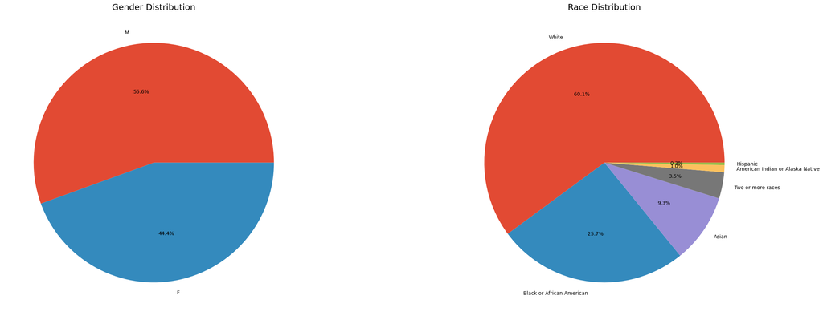

```python
df_ter = df[df['termreason'] == 'career change']
ge_dist = df_ter['sex'].value_counts()
rc_dist = df['racedesc'].value_counts()

plt.figure(figsize = (27,27))
plt.subplot(1,2,1)
ge_dist.plot(kind = 'pie', autopct = '%1.1f%%')
plt.title('Gender Distribution', fontsize = 17)
plt.xlabel('')
plt.ylabel('')

plt.subplot(1,2,2)
rc_dist.plot(kind = 'pie', autopct = '%1.1f%%')
plt.title('Race Distribution', fontsize = 17)
plt.xlabel('')
plt.ylabel('')
plt.subplots_adjust(wspace = 0.5)
plt.show()
```

13. How many employees of each **gender** and **race** left because of medical issues?

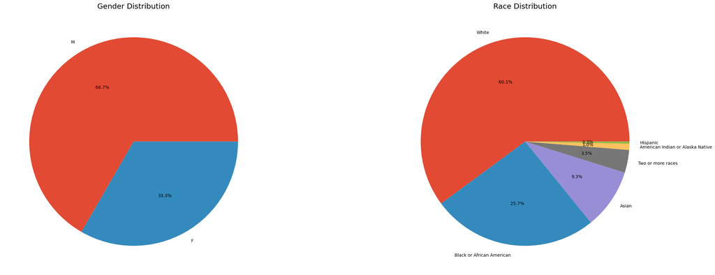

```python
df_ter = df[df['termreason'] == 'medical issues']
ge_dist = df_ter['sex'].value_counts()
rc_dist = df['racedesc'].value_counts()

plt.figure(figsize = (27,27))
plt.subplot(1,2,1)
ge_dist.plot(kind = 'pie', autopct = '%1.1f%%')
plt.title('Gender Distribution', fontsize = 17)
plt.xlabel('')
plt.ylabel('')

plt.subplot(1,2,2)
rc_dist.plot(kind = 'pie', autopct = '%1.1f%%')
plt.title('Race Distribution', fontsize = 17)
plt.xlabel('')
plt.ylabel('')
plt.subplots_adjust(wspace = 0.5)
plt.show()
```

14. How many employees of each **gender** and **race** were fired for gross misconduct?

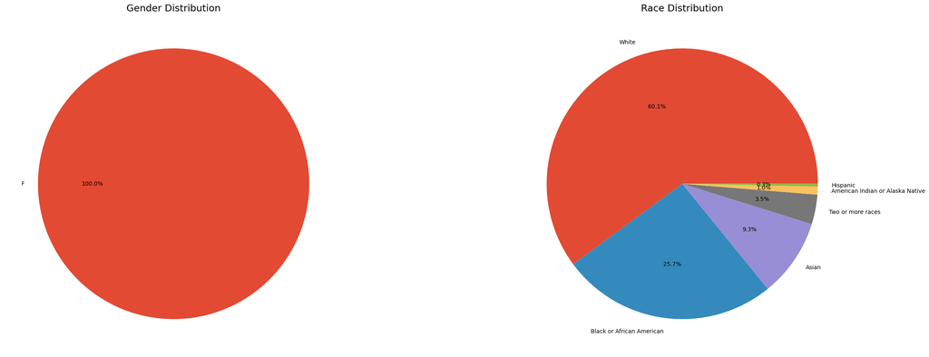

```python
df_ter = df[df['termreason'] == 'gross misconduct']
ge_dist = df_ter['sex'].value_counts()
rc_dist = df['racedesc'].value_counts()

plt.figure(figsize = (27,27))
plt.subplot(1,2,1)
ge_dist.plot(kind = 'pie', autopct = '%1.1f%%')
plt.title('Gender Distribution', fontsize = 17)
plt.xlabel('')
plt.ylabel('')

plt.subplot(1,2,2)
rc_dist.plot(kind = 'pie', autopct = '%1.1f%%')
plt.title('Race Distribution', fontsize = 17)
plt.xlabel('')
plt.ylabel('')
plt.subplots_adjust(wspace = 0.5)
plt.show()
```

15. How many employees of each **gender** and **race** left because they retired?

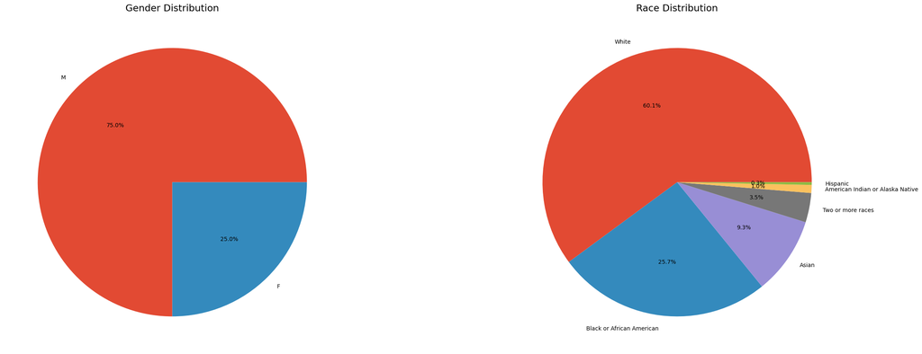

```python
df_ter = df[df['termreason'] == 'retiring']
ge_dist = df_ter['sex'].value_counts()
rc_dist = df['racedesc'].value_counts()

plt.figure(figsize = (27,27))
plt.subplot(1,2,1)
ge_dist.plot(kind = 'pie', autopct = '%1.1f%%')
plt.title('Gender Distribution', fontsize = 17)
plt.xlabel('')
plt.ylabel('')

plt.subplot(1,2,2)
rc_dist.plot(kind = 'pie', autopct = '%1.1f%%')
plt.title('Race Distribution', fontsize = 17)
plt.xlabel('')
plt.ylabel('')
plt.subplots_adjust(wspace = 0.5)
plt.show()
```

## Recruitment Analysis

```python
df_mar = df[df['birth_year'] < 2005]
df_mar['age'] = 2024 - df_mar['birth_year']
a = pd.DataFrame(df_mar.groupby('recruitmentsource')['age'].mean().sort_values(ascending = False))
a.columns = ['Average Age']
a
```

| recruitmentsource | Average Age |
| --- | --- |
| Diversity Job Fair | 47.272727 |
| On-line Web application | 47.000000 |
| Other | 47.000000 |
| Google Search | 44.157895 |
| Employee Referral | 42.461538 |
| LinkedIn | 42.000000 |
| CareerBuilder | 41.700000 |
| Indeed | 41.272727 |
| Website | 39.875000 |

2. What is the engagement survey score grouped by recruitment source?

```python
a = pd.DataFrame(df_mar.groupby('recruitmentsource')['engagementsurvey'].mean().sort_values(ascending = False))
a.columns = ['Average Rating']
a
```

| recruitmentsource | Average Rating |
| --- | --- |
| On-line Web application | 5.000000 |
| Other | 4.550000 |
| Website | 4.391250 |
| Employee Referral | 4.381538 |
| Diversity Job Fair | 4.126364 |
| Google Search | 4.123684 |
| CareerBuilder | 4.119000 |
| LinkedIn | 4.043611 |
| Indeed | 3.954091 |

3. How many employees were hired in each department for each hire month?

```python
pd.DataFrame(df.groupby(['department', 'hire_month'])['hire_month'].count())
```

| department | hire_month | hire_month |
| --- | --- | --- |
| Admin Offices | February | 2 |
|  | January | 3 |
|  | May | 1 |
|  | October | 1 |
|  | September | 2 |
| Executive Office | July | 1 |
| IT/IS | April | 4 |
|  | December | 1 |
|  | February | 9 |
|  | January | 13 |
|  | July | 1 |
|  | June | 3 |
|  | March | 8 |
|  | May | 1 |
|  | November | 5 |
|  | October | 2 |
|  | September | 3 |
| Production | April | 22 |
|  | August | 15 |
|  | February | 16 |
|  | January | 33 |
|  | July | 37 |
|  | June | 5 |
|  | March | 8 |
|  | May | 24 |
|  | November | 17 |
|  | October | 4 |
|  | September | 28 |
| Sales | April | 1 |
|  | August | 4 |
|  | February | 2 |
|  | January | 4 |
|  | July | 4 |
|  | March | 3 |
|  | May | 6 |
|  | November | 1 |
|  | September | 6 |
| Software Engineering | August | 1 |
|  | February | 2 |
|  | January | 1 |
|  | July | 1 |
|  | May | 1 |
|  | November | 5 |

## Feature Engineering

```python
df.columns
```

```
Index(['employee_name', 'empid', 'marriedid', 'maritalstatusid', 'genderid',
       'empstatusid', 'deptid', 'perfscoreid', 'fromdiversityjobfairid',
       'salary', 'termd', 'positionid', 'position', 'state', 'zip', 'dob',
       'sex', 'maritaldesc', 'citizendesc', 'hispaniclatino', 'racedesc',
       'dateofhire', 'dateoftermination', 'termreason', 'employmentstatus',
       'department', 'managername', 'managerid', 'recruitmentsource',
       'performancescore', 'engagementsurvey', 'empsatisfaction',
       'specialprojectscount', 'lastperformancereview_date', 'dayslatelast30',
       'absences', 'hire_year', 'termination_year', 'hire_month',
       'termination_month', 'hire_day', 'termination_day', 'birth_year',
       'birth_month', 'birth_day'],
      dtype='object')
```

*creating copy of the dataset*

```python
d2 = df[['salary','position', 'state', 'sex', 'maritaldesc', 'citizendesc', 'racedesc', 'hire_year', 'department', 'managername',
         'recruitmentsource', 'specialprojectscount', 'empsatisfaction', 'performancescore']]
d2.head(4)
```

|  | salary | position | state | sex | maritaldesc | citizendesc | racedesc | hire_year | department | managername | recruitmentsource | specialprojectscount | empsatisfaction | performancescore |
| --- | --- | --- | --- | --- | --- | --- | --- | --- | --- | --- | --- | --- | --- | --- |
| 0 | 62506 | Production Technician I | MA | M | Single | US Citizen | White | 2011 | Production | Michael Albert | LinkedIn | 0 | 5 | Exceeds |
| 1 | 104437 | Sr. DBA | MA | M | Married | US Citizen | White | 2015 | IT/IS | Simon Roup | Indeed | 6 | 3 | Fully Meets |
| 2 | 64955 | Production Technician II | MA | F | Married | US Citizen | White | 2011 | Production | Kissy Sullivan | LinkedIn | 0 | 3 | Fully Meets |
| 3 | 64991 | Production Technician I | MA | F | Married | US Citizen | White | 2008 | Production | Elijiah Gray | Indeed | 0 | 5 | Fully Meets |

```python
len(d2.columns)
```

```
14
```

*label encoding features*

```python
from sklearn.preprocessing import LabelEncoder
e = LabelEncoder()
d2['position'] = e.fit_transform(d2['position'])
d2['state'] = e.fit_transform(d2['state'])
d2['sex'] = e.fit_transform(d2['sex'])
d2['maritaldesc'] = e.fit_transform(d2['maritaldesc'])
d2['citizendesc'] = e.fit_transform(d2['citizendesc'])
d2['racedesc'] = e.fit_transform(d2['racedesc'])
d2['department'] = e.fit_transform(d2['department'])
d2['managername'] = e.fit_transform(d2['managername'])
d2['recruitmentsource'] = e.fit_transform(d2['recruitmentsource'])
d2['performancescore'] = e.fit_transform(d2['performancescore'])
```

*verifying encoding*

```python
d2.head(4)
```

|  | salary | position | state | sex | maritaldesc | citizendesc | racedesc | hire_year | department | managername | recruitmentsource | specialprojectscount | empsatisfaction | performancescore |
| --- | --- | --- | --- | --- | --- | --- | --- | --- | --- | --- | --- | --- | --- | --- |
| 0 | 62506 | 22 | 10 | 1 | 3 | 2 | 5 | 2011 | 3 | 17 | 5 | 0 | 5 | 0 |
| 1 | 104437 | 30 | 10 | 1 | 1 | 2 | 5 | 2015 | 2 | 19 | 4 | 6 | 3 | 1 |
| 2 | 64955 | 23 | 10 | 0 | 1 | 2 | 5 | 2011 | 3 | 15 | 5 | 0 | 3 | 1 |
| 3 | 64991 | 22 | 10 | 0 | 1 | 2 | 5 | 2008 | 3 | 8 | 4 | 0 | 5 | 1 |

*split data into x and y*

```python
x = d2.drop(columns = ['performancescore'])
y = d2['performancescore']
```

#### *selecting best x feaatures*

```python
from sklearn.feature_selection import SelectKBest, chi2, f_classif
selector = SelectKBest(score_func = chi2, k = 4)
x_new = selector.fit_transform(x, y)

# Get the boolean mask of selected features
selected_mask = selector.get_support()

# Get the column names of the selected features
selected_columns = x.columns[selected_mask]

print("Selected Features:")
print(selected_columns)
```

```
Selected Features:
Index(['salary', 'position', 'managername', 'specialprojectscount'], dtype='object')
```

*split data into train and test*

```python
from sklearn.model_selection import train_test_split as t
x_train, x_test, y_train, y_test = t(x_new, y, test_size = 0.2, random_state = 1)
```

#### *scaling x values*

```python
from sklearn.preprocessing import StandardScaler
s = StandardScaler()
x_train_scaled = s.fit_transform(x_train)
x_test_scaled = s.fit_transform(x_test)
```

#### *function to evaluate models*

```python
from sklearn.metrics import accuracy_score, f1_score
def evaluator(pred):
    print(f"accuracy score: {accuracy_score(y_test, pred)}")
    print(f"f1 score: {f1_score(y_test, pred, average = 'weighted')}")
```

#### *Training and Evaluating Models*

*first model:* *logistic regression***

```python
from sklearn.linear_model import LogisticRegression
l = LogisticRegression()

# training model
l.fit(x_train_scaled, y_train)

# creating predictor
lp = l.predict(x_test_scaled)

# evaluating model
evaluator(lp)
```

```
accuracy score: 0.746031746031746
f1 score: 0.6375180375180375
```

*second model:* *kneighbor classifier***

```python
from sklearn.neighbors import KNeighborsClassifier
from sklearn.model_selection import GridSearchCV

# hyperparameters
p1 = {
    'n_neighbors':[4, 5, 10, 12],
    'weights':['uniform', 'distance', None],
    'leaf_size': [10, 20, 30, 40, 50],
    'n_jobs':[None, 2, 5]
}

# training model
k = GridSearchCV(KNeighborsClassifier(), param_grid = p1, cv = 5)
k.fit(x_train_scaled, y_train)

# creating predictor
kp = k.predict(x_test_scaled)

# evaluate model
evaluator(kp)
```

```
accuracy score: 0.746031746031746
f1 score: 0.6375180375180375
```

```python
# best parameters
k.best_params_
```

```
{'leaf_size': 10, 'n_jobs': None, 'n_neighbors': 12, 'weights': 'uniform'}
```

*third model:* *support vector classifier***

```python
from sklearn.svm import SVC

# hyperparameters
p2 = {
    'C': [0.1, 1, 10, 20],
    'kernel': ['linear', 'poly', 'rbf', 'sigmoid'],
    'degree': [2, 3, 4, 10]
}

# train model
s = GridSearchCV(SVC(), param_grid = p2, cv = 5)
s.fit(x_train_scaled, y_train)

# create predictor
sp = s.predict(x_test_scaled)

# evaluate model
evaluator(sp)
```

```
accuracy score: 0.746031746031746
f1 score: 0.6609053497942388
```

```python
# best parameters
s.best_params_
```

```
{'C': 1, 'degree': 3, 'kernel': 'poly'}
```

*fourth model:* *random forest classifier***

```python
from sklearn.ensemble import RandomForestClassifier

# hyperparameters
p3 = {
    'n_estimators':[50, 100, 200, ],
    'min_samples_split':[2, 4, 6, 8, 10],
    'max_depth':[None, 5, 10, 15]
}

# train model
r = GridSearchCV(RandomForestClassifier(), param_grid = p3, cv = 3)
r.fit(x_train_scaled, y_train)

# create predictor
rp = r.predict(x_test_scaled)

# evaluate model
evaluator(rp)
```

```
accuracy score: 0.746031746031746
f1 score: 0.6375180375180375
```

```python
# best parameters
r.best_params_
```

```
{'max_depth': 5, 'min_samples_split': 4, 'n_estimators': 50}
```

*fifth model:* *xgboost classifier***

```python
from xgboost import XGBClassifier

# hyperparameters
p3 = {
    'n_estimators': [100, 200, 300, 500],
    'max_depth': [None, 5, 10],
    'min_child_weight': [3, 5, 10],
    'learning_rate': [0.01, 0.1, 1, 2],
}

# train model
xg = GridSearchCV(XGBClassifier(), param_grid = p3, cv = 5)
xg.fit(x_train_scaled, y_train)

# create predictor
xp = xg.predict(x_test_scaled)

# evaluate model
evaluator(xp)
```

```
accuracy score: 0.746031746031746
f1 score: 0.6375180375180375
```

```python
# best parameters
xg.best_params_
```

```
{'learning_rate': 0.01,
 'max_depth': None,
 'min_child_weight': 5,
 'n_estimators': 100}
```

### predictions with best model

```python
pd.DataFrame(x_new).head(6)
```

|  | 0 | 1 | 2 | 3 |
| --- | --- | --- | --- | --- |
| 0 | 62506 | 22 | 17 | 0 |
| 1 | 104437 | 30 | 19 | 6 |
| 2 | 64955 | 23 | 15 | 0 |
| 3 | 64991 | 22 | 8 | 0 |
| 4 | 50825 | 22 | 20 | 0 |
| 5 | 57568 | 22 | 1 | 0 |

```python
df[['salary', 'position', 'managername', 'specialprojectscount']].head(7)
```

|  | salary | position | managername | specialprojectscount |
| --- | --- | --- | --- | --- |
| 0 | 62506 | Production Technician I | Michael Albert | 0 |
| 1 | 104437 | Sr. DBA | Simon Roup | 6 |
| 2 | 64955 | Production Technician II | Kissy Sullivan | 0 |
| 3 | 64991 | Production Technician I | Elijiah Gray | 0 |
| 4 | 50825 | Production Technician I | Webster Butler | 0 |
| 5 | 57568 | Production Technician I | Amy Dunn | 0 |
| 6 | 95660 | Software Engineer | Alex Sweetwater | 4 |

```python
new_employee = np.array([75000,22,17,4])
print('performance of a new employee from support vector model is {}'.format(s.predict(new_employee.reshape(1,-1))))
```

```
performance of a new employee from support vector model is [0]
```